# Знакомство с многомерными данными

## Вы сможете

- Объяснить почему для некоторых задач больше подходят многомерные данные
- Объяснить суть понятия “многомерное пространство признаков”
- Представить многомерные данные в виде матриц описания значений признаков для объектов
- Оценить сходство/различие между объектами с помощью специальных коэффициентов
- Описать *взаиморасположение* объектов в многомерном пространстве признаков с помощью матриц
- Визуализировать взаиморасположение объектов с помощью простейших методов

## Общая характеристика многомерных методов

## Почему нужны многомерные методы?

Пусть у нас имеется две группы объектов, у которых мы изучили некий признак. Мы хотим тестировать гипотезу о том, что эти две группы различаются.

Вспомним логику тестирования гипотез.

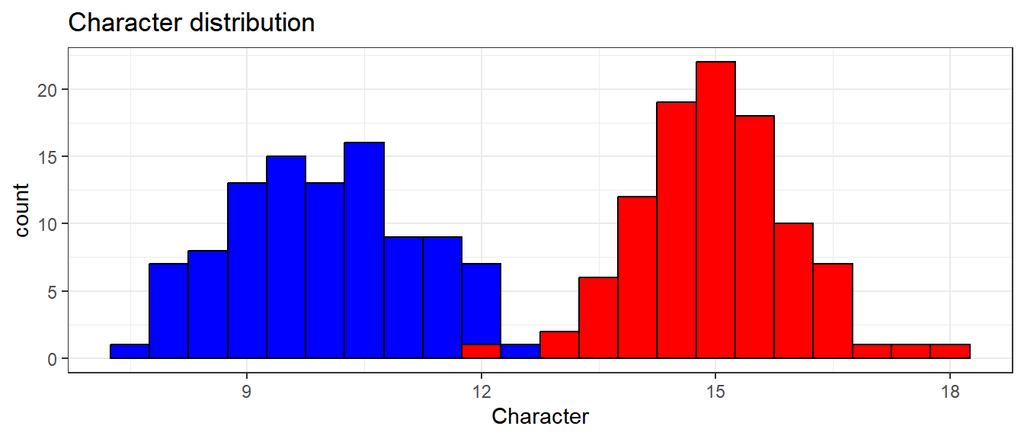

## Почему нужны многомерные методы?

Теперь представим, что наш объект, по своей природе, не может быть описан только по одному признаку

- Сообщества (признаки - виды)
- Форма тела (признаки - размеры тех или иных частей)
- Социальная активность животного (признаки - проявление того или иного паттерна)
- Общественное мнение (признаки - ответы на разные вопросы анкет)
- Транскриптом (признаки - транскрипты)

## Почему нужны многомерные методы?

Предположим, что объекты характеризуются только двумя признаками

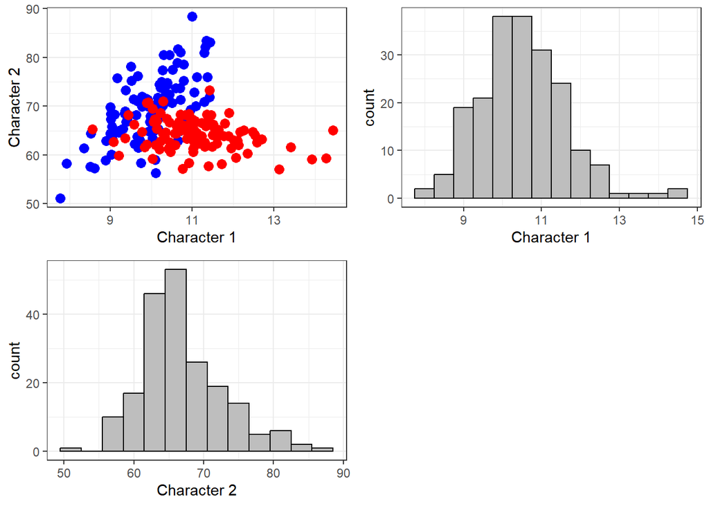

## Какие задачи решаются методами могомерной статистики?

- Выявление взаимоотношений (сходства-различия) между объектами (или признаками):
- Классификация (Кластерный анализ)
- Ординация. В том числе картирование пространственно выраженных объектов (nMDS, PCA).
- Тестирование гипотез о различиях между группами объектов (ANOSIM, PERMANOVA).
- Выявление связи между группами признаков (тест Мантела, BIOENV, RDA, CCA).

## Признаки и объекты

Данные представляются в виде таблицы (матрицы), где строками являются объекты (Objects), а столбцами признаки (Descriptors).

## R и Q анализы

- R-анализ: Выясняем взаимоотношения между признаками
- Q-анализ: Выясняем взаимоотношения между объектами

## Геометрическая интерпретация Q-анализа

- Признаки - оси
- Объекты - точки

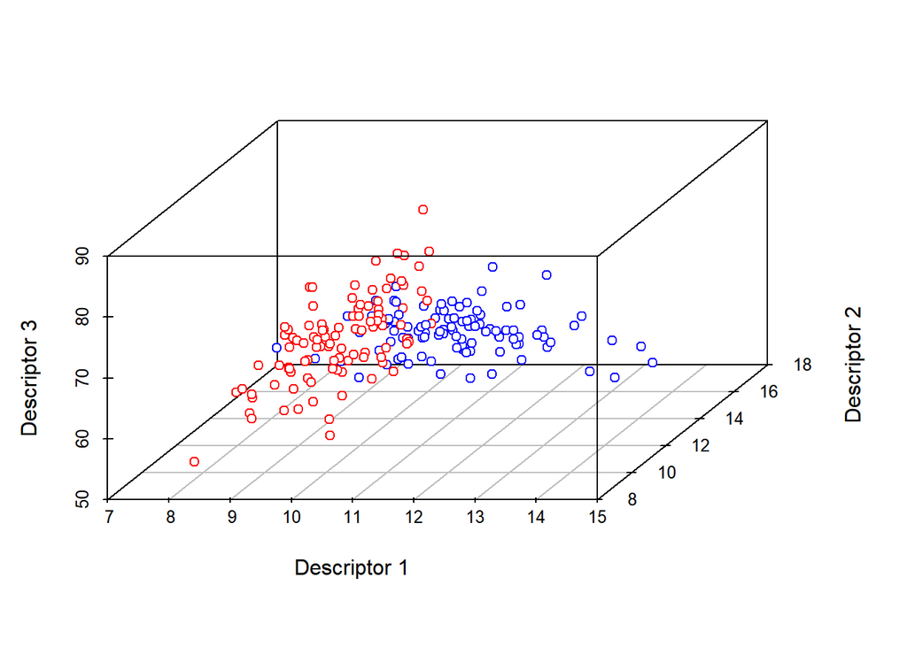

## Описание расположения объектов в многомерном пространстве признаков

В большинстве случаев нас интересуют не абсолютные значения координат (признаков), а *взаиморасположение* точек в многомерном пространстве.

Существует два основных способа описания.

## Способ 1. Геометрическое описание (линейная алгебра)

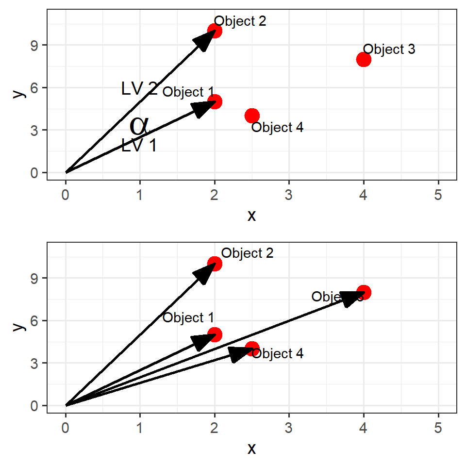

Для описания взаиморасположения точек необходимо иметь два набора данных

Матрицу углов между векторами (косинусов углов)

\[\begin{pmatrix} \alpha_{11} & \alpha_{12} & \cdots & \alpha_{1n} \\ \alpha_{21} & \alpha_{22} & \cdots & \alpha_{2n} \\ \vdots & \vdots & \ddots & \vdots \\ \alpha_{n1} & \alpha_{n2} & \cdots & \alpha_{nn} \end{pmatrix}\]

Ряд длин векторов \[\begin{vmatrix} LV1 \\ LV2 \\ ... \\ LVn \end{vmatrix}\]

Этот способ описания, с разными вариациями, будет применяться в методах *PCA, CA, CCA, RDA*

## Способ 2. Через вычисление матрицы попарных расстояний (Similarity/Dissimilarity matrix)

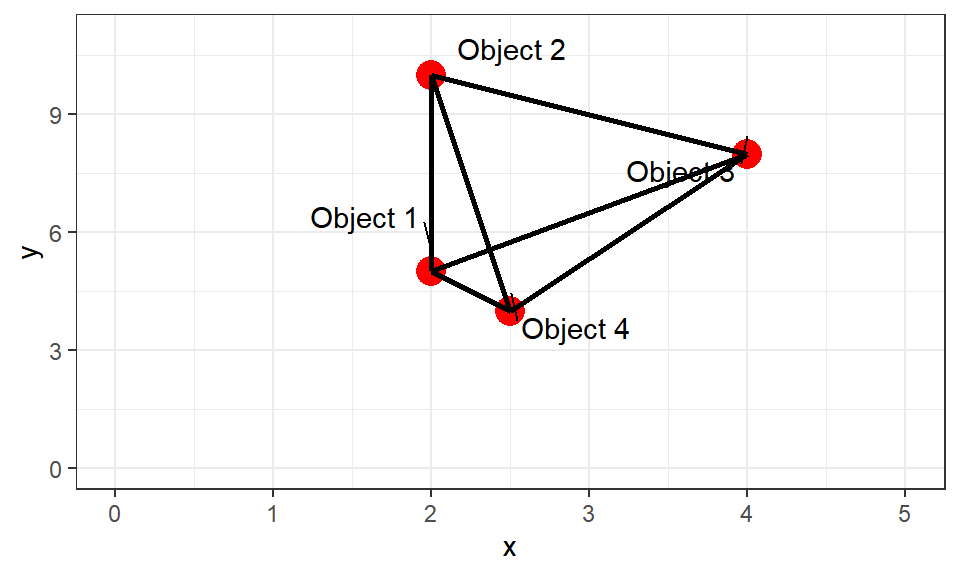

В анализ вовлекается матрица попарных расстояний (сходств) между объектами. Эта матрица однозначно описывает взаиморасположение между объектами.

Этот способ представления взаиморасположения лежит в основе *Иерархического кластерного анализа, MDS, теста Мантела, ANOSIM, PERMANOVA, процедуры BIOENV*

## Облако точек в n-мерном пространстве

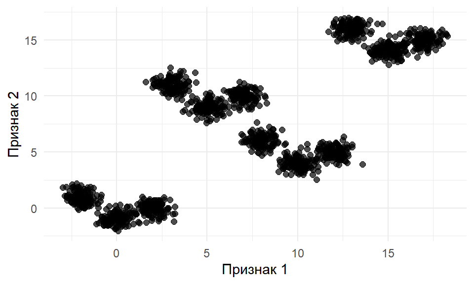

Что может лежать в основе такого паттерна расположения точек?

## Простейший многомерный анализ

## Простейшая матрица значений признаков

Два объекта и два признака

|  | Признак А | Признак B |
| --- | --- | --- |
| Объект 1 | 1 | 1 |
| Объект 2 | 2 | 2 |

## Геометрическая интерпретация простейшей матрицы

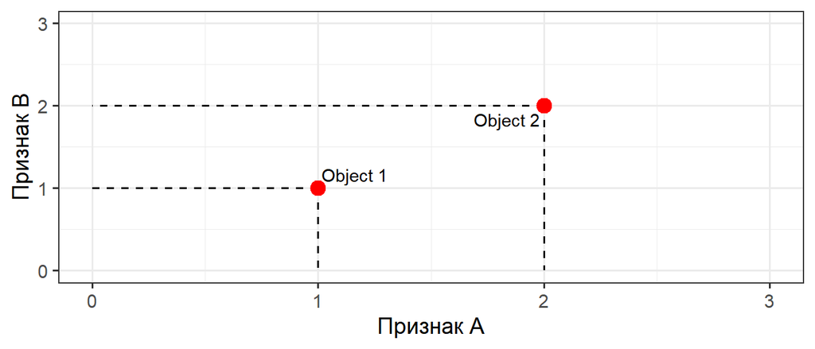

## Евклидово расстояние

Это простейший способ описания расстояния между объектами в пространстве признаков.

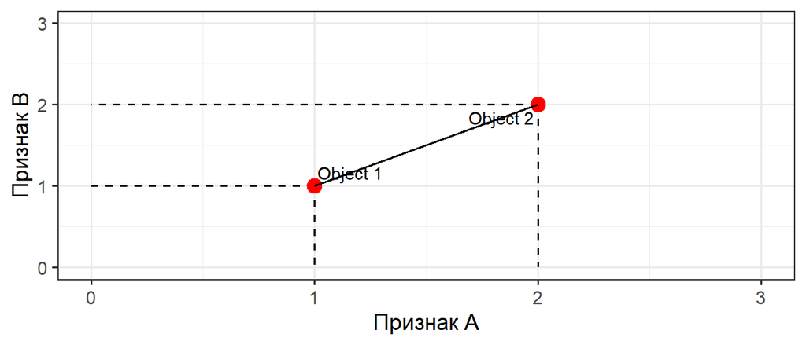

По теореме Пифагора

- \[ D = \sqrt{(A_2 - A_1)^2 + (B_2 - B_1)^2} \]
- Расстояние между объектами выражается просто числом D = 1.414
- **At!** Эта мера различия между объектами не единственная, и далеко не всегда правильная (об этом далее).

## Усложняем задачу: объектов становится больше двух

| Объект | Признак А | Признак B |
| --- | --- | --- |
| Object 1 | 2.0 | 5 |
| Object 2 | 2.0 | 10 |
| Object 3 | 4.0 | 8 |
| Object 4 | 2.5 | 4 |

## Геометрическая интерпретация

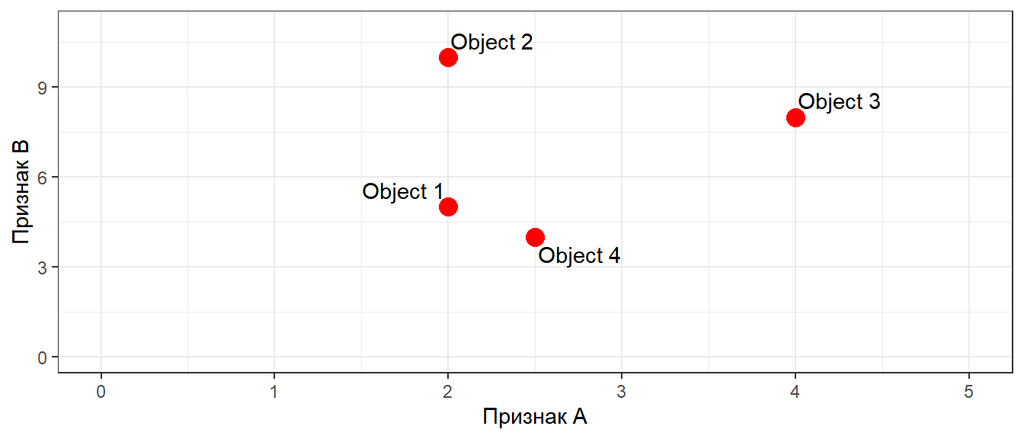

## Матрица расстояний (Similarity/Dissimilarity matrix)

Когда объектов больше двух, то расстояния между объектами можно выразить **матрицей расстояний**.

```
##     1   2   3   4
## 1 0.0 5.0 3.6 1.1
## 2 5.0 0.0 2.8 6.0
## 3 3.6 2.8 0.0 4.3
## 4 1.1 6.0 4.3 0.0
```

Охарактеризуйте эту матрицу

- Квадратная матрица
- Симметричная матрица

## Усложняем задачу: признаков становится больше двух

| Объект | Признак А | Признак B | Признак С | Признак D |
| --- | --- | --- | --- | --- |
| Object 1 | 2.0 | 5 | 100 | 0.10 |
| Object 2 | 2.0 | 10 | 258 | 0.01 |
| Object 3 | 4.0 | 8 | 122 | 0.09 |
| Object 4 | 2.5 | 4 | 10000 | 0.15 |

## Геометрическая интрепретация

Облако точек в n-мерном пространстве значений признаков.

**At!** Не пытайтесь представить n-мерный объект… Просто работайте с ним.

- Warning

[figure not shown]

## Эвклидово расстояние в n-мерном пространстве

\[D = \sqrt{\sum(x_{i,j} - x_{i,k})^2}\]

В n-мерном пространстве соблюдаются те же законы, что и на плоскости.

## Три способа изображения матрицы расстояний

```
##        1      2      3      4
## 1    0.0  158.1   22.3 9900.0
## 2  158.1    0.0  136.0 9742.0
## 3   22.3  136.0    0.0 9878.0
## 4 9900.0 9742.0 9878.0    0.0
```

```
##        1      2      3      4
## 1    0.0
## 2  158.1    0.0
## 3   22.3  136.0    0.0
## 4 9900.0 9742.0 9878.0    0.0
```

```
##        1      2      3
## 2  158.1
## 3   22.3  136.0
## 4 9900.0 9742.0 9878.0
```

Количество значимых чисел в треугольной матрице:

\[N = \frac{n^2 - n}{2}\]

## Матрица расстояний в развернутом виде (Unfolded dissimilarity matrix)

```
##        1      2      3
## 2  158.1
## 3   22.3  136.0
## 4 9900.0 9742.0 9878.0
```

```
## [1]  158.1   22.3 9900.0  136.0 9742.0 9878.0
```

## Результаты простейшего могомерного анализа

**Исходная матрица признаков**

| Объект | Признак А | Признак B | Признак С | Признак D |
| --- | --- | --- | --- | --- |
| Object 1 | 2.0 | 5 | 100 | 0.10 |
| Object 2 | 2.0 | 10 | 258 | 0.01 |
| Object 3 | 4.0 | 8 | 122 | 0.09 |
| Object 4 | 2.5 | 4 | 10000 | 0.15 |

**Матрица расстояний**

```
##        1      2      3
## 2  158.1
## 3   22.3  136.0
## 4 9900.0 9742.0 9878.0
```

- Какие объекты наиболее похожи друг на друга?
- Какие объекты наиболее различны?
- В чем проблема данного анализа?

## Простейший анализ реальных многомерных данных

## Пример: Сообщества бентоса акватории Долгой губы (о. Б. Соловецкий, Белое море)

В этом примере используется сокращенный набор данных о бентосе Долгой губы (Нинбург, 1990; Хайтов и др., 2013) — только численность наиболее обильных видов на 68 станциях.

- `dolg_abundance.txt` — данные об обилии 25 видов
- `dolg_hydrology.txt` — данные о 4 гидрологических характеристиках: глубина, Температура придонной воды, Соленость, Степень гидратации грунта

[figure not shown]

## Читаем данные

```r
abund <- read.table("data/dolg_abundance.txt", skip = 1, header = TRUE, sep = ";")
hydrol <- read.table("data/dolg_hydrology.txt", skip = 1, header = TRUE, sep = ";")
```

## Вопрос для многомерного анализа

Существуют ли группировки описаний, сходных по населению?

Задание: Нарисуйте на бумаге как, по вашему мнению, должны располагаться объекты (описания-станции) в n-мерном пространстве признаков, если существует две группировки.

## Подготовка данных для анализа

Переменные могут быть измерены в разных шкалах

- численность, биомасса и проективное покрытие разных организмов
- температура воды, соленость и концентрация биогенов
- Размеры частей тела, количество частей тела, площадь частей тела

Для таких случаев необходима стандартизация величин. Этот прием будет постоянно применяться при многомерных анализах, основанных на матричной алгебре.

\[x_{stand} = \frac{x_i - \bar{x}}{\sigma_x}\]

- **Вопрос:** Какими свойствами обладают стандартизованные величины?
- Среднее значение равно нулю.
- Среднеквадратичное отклонение равно единице.

## Подготовка данных для анализа

В ряде случаев (особенно в экологических исследованиях) необходимо перевести абсолютные значения в относительные (доли от суммы или от максимума)

\[x_{rel} = \frac{x_i}{\sum x_i} \times 100 \%\]

\[x_{rel} = \frac{x_i}{max(x_i)} \times 100 \%\]

## Подготовка данных для анализа

Часто возникает ситуация, когда один признак (или несколько признаков) имеет существенно более высокие абсолютные значения, чем все остальные, или варьирует в более широких пределах, чем остальные признаки.

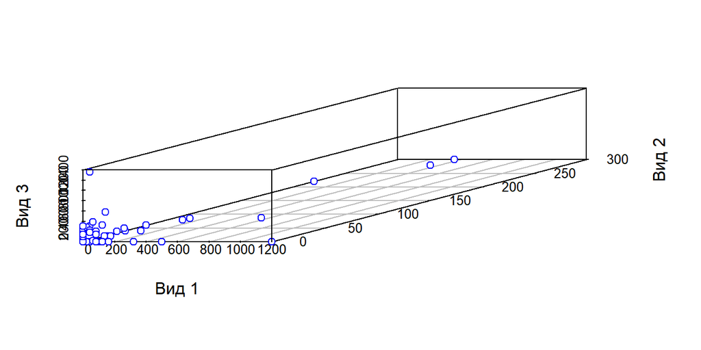

В такой ситуации необходима *трансформация* , которая “уравнивает” силу влияния признаков.

По силе эффекта трансформирующие функции распределяются так:

Отсутствие трансформации \(\Rightarrow\) Квадратный корень \(\Rightarrow\) Корень четвертой степени \(\Rightarrow\) Логарифм \(log(x_i +1)\) \(\Rightarrow\) Присутствие отсутствие (1, 0)

## Задание:

На основе датасета, содержащего данные по обилию видов, создайте матрицу, содержащую относительные величины (доли обилия каждого вида в общем обилии организмов на данной станции)

Hint: Воспользуйтесь функцией `apply()`

## Решение

```r
total <- apply(abund[, -1], MARGIN = 1,FUN = sum)
abund_rel <- abund[, -1] / total

head(abund_rel[,1:3])
```

```
##   Eteone_longa Nemertini Harmothoe_imbricata
## 1       0.0000   0.00772              0.0232
## 2       0.0000   0.00000              0.0000
## 3       0.0000   0.00000              0.0000
## 4       0.0000   0.00000              0.0000
## 5       0.0000   0.02857              0.0000
## 6       0.0143   0.01429              0.0000
```

## Знакомимся с пакетом `vegan` (Oksanen et al., 2015)

```r
library (vegan)
```

- Пакет `vegan` позволяет проводить много типов многомерных анализов (но не все!).
- Ориентирован на экологические данные, отсюда много экологических терминов (признаки – “species”, объекты – “sites”)
- Исчерпывающее описание методов, реализованных в `vegan`, дается в “Numerical ecology” (Legendre & Legendre, 2012)
- Альтернатива – пакет `ade4`

## Подготовка данных в пакете `vegan`

Относительные величины

```r
abund_rel <- decostand(abund[,-1], method = "total", MARGIN = 1)
head(abund_rel[, 1:3])
```

```
##   Eteone_longa Nemertini Harmothoe_imbricata
## 1       0.0000   0.00772              0.0232
## 2       0.0000   0.00000              0.0000
## 3       0.0000   0.00000              0.0000
## 4       0.0000   0.00000              0.0000
## 5       0.0000   0.02857              0.0000
## 6       0.0143   0.01429              0.0000
```

## Задание

С помощью пакета `vegan` создайте еще два датасета:

- `abund_stand` – Стандартизованные величины обилий видов
- `abund_log` – Логарифмированные величины обилий видов

## Решение: стандартизация в `vegan`

```r
abund_stand <- decostand(abund[,-1], method = "standardize", MARGIN = 2)
head(abund_stand[, 1:3])
```

```
##   Eteone_longa Nemertini Harmothoe_imbricata
## 1       -0.329    0.6878               2.783
## 2       -0.329   -0.5594              -0.508
## 3       -0.329   -0.5594              -0.508
## 4       -0.329   -0.5594              -0.508
## 5       -0.329    0.6878              -0.508
## 6        0.118    0.0642              -0.508
```

## Решение: log-трансформация в `vegan`

```r
abund_log <-  decostand(abund[,-1], method = "log", MARGIN = 2)
head(abund_log[, 1:3])
```

```
##   Eteone_longa Nemertini Harmothoe_imbricata
## 1         0.00      6.32                7.91
## 2         0.00      0.00                0.00
## 3         0.00      0.00                0.00
## 4         0.00      0.00                0.00
## 5         0.00      6.32                0.00
## 6         5.32      5.32                0.00
```

## Матрицы расстояний в пакете `vegan`

```r
dist_init <- vegdist(abund[,-1], method = "euclidean")
dist_stand <- vegdist(abund_stand, method = "euclidean")
dist_log <- vegdist(abund_log, method = "euclidean")
dist_rel <- vegdist(abund_rel, method = "euclidean")
```

## Существуют ли группировки в n-мерном облаке точек?

Самый простой анализ - частотное распределение расстояний между объектами.  
Позволяет понять есть ли сгущения в облаке точек в n-мерном пространстве признаков.

**Задание:** Создайте вектор, соответствующий развернутой (unfolded) матрице эвклидовых расстояний, основанной на относительных обилиях видов, и постройте частотную гистограмму для этого вектора.

## Решение

```r
disatances <- data.frame(Init = as.numeric(dist_init),
                        Stand = as.numeric(dist_stand),
                        Log = as.numeric(dist_log),
                        Rel = as.numeric(dist_rel))


Pl_hist <- ggplot(disatances) + geom_histogram()
Pl_init <- Pl_hist + aes(x = Init) + ggtitle("Исходные данные") + labs(x = "Евклидово расстояние")
Pl_stand <- Pl_hist + aes(x = Stand) + ggtitle("Стандартизация") + labs(x = "Евклидово расстояние")
Pl_log <- Pl_hist + aes(x = Log)  + ggtitle("Логарифмирование")+ labs(x = "Евклидово расстояние")
Pl_rel <- Pl_hist + aes(x = Rel) + ggtitle("Относительные величины")+ labs(x = "Евклидово расстояние")
```

## Существуют ли группировки?

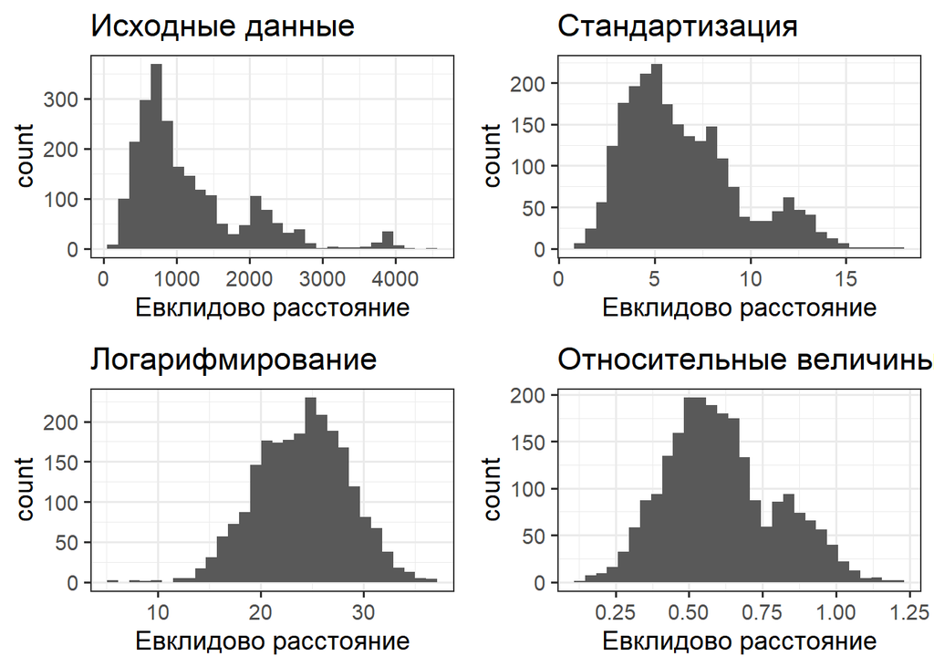

## Структура облака точек

Если в n-мерном облаке точек присутствуют несколько “сгущений”, то расстояния между объектами делятся на внутригрупповые (пик в области малых значений расстояний) и межгрупповые (пик в области высоких значений)

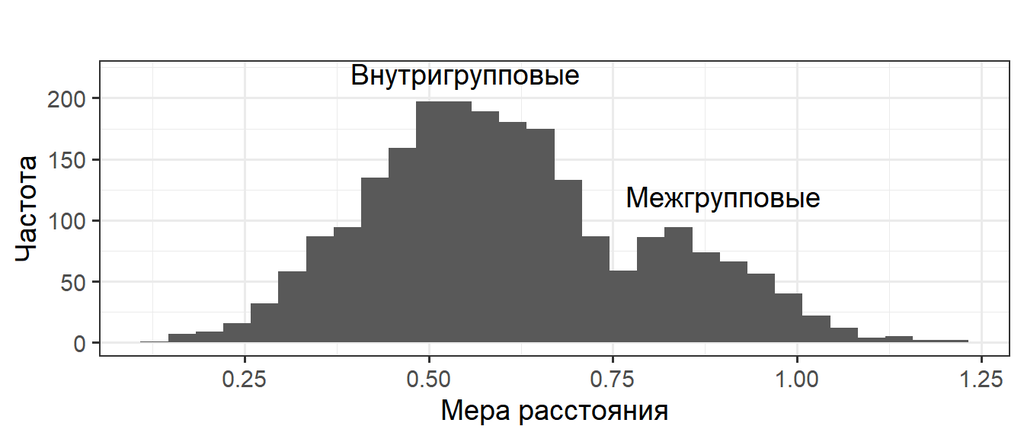

## Меры сходства и различия между объектами (Resemblance coefficients)

## От того в чем измерено различие многое зависит

Мы уже знаем, что от способа выражения признаков очень многое зависит.

Однако еще сильнее анализ зависит от того с помощью какой величины (Resemblance coefficients) описывается степень различия между объектам.

**Задание:** 1. На базе датасета `abund_log`, используя функцию `vegdist()` рассчитайте матрицу различий между объектами (`dist_eucl`), основанную на евклидовом расстоянии.

1. На том же датасете постройте матрицу различий (`dist_bray`), основанную на методе, называемом ‘bray’.
2. Разверните обе матрицы в векторы.
3. Постройте для этих векторов частотные диаграммы.

## Решение

```r
dist_eucl <- vegdist(abund_log, method = "euclidean")
dist_bray <- vegdist(abund_log, method = "bray")

dists <- data.frame(Euclidean = as.numeric(dist_eucl),
                    Bray = as.numeric(dist_bray))

Pl_hist <- ggplot(dists) + geom_histogram()
Pl_eucl <- Pl_hist + aes(x = Euclidean)
Pl_bray <- Pl_hist + aes(x = Bray)
```

## Решение

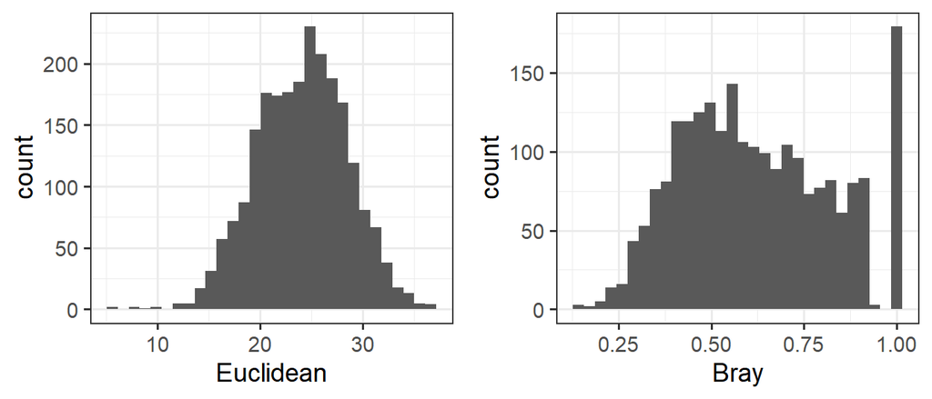

```r
grid.arrange(Pl_eucl, Pl_bray, ncol = 2)
```

## Сходства и различия

- Сходство (S) достигает максимума, когда объекты обладают идентичными признаками, различиe (D), наоборот - достигает минимума.
- Обычно (но не всегда) коэффициенты сходства распределены от 0 до 1.
- Тогда \(D = 1 - S\), или \(D = \sqrt{1 - S}\), или \(D = \sqrt{1-S^2}\).
- Показатели можно нормировать. \(D_{norm} = \frac{D}{D_{max}}\), или \(D_{norm} = \frac{D - D_{min}}{D_{max} - D_{min}}\).

В большинстве случаев нас будут интересовать меры различия между объектами

## Проблема двойных нулей (Double zeros probem)

```
##         D1 D2 D3 D4 D5 D6 D7 D8 D9 D10
## Object1  0  0  0  0  0  0  0  2  2   1
## Object2  0  0  0  0  0  4  5  0  0   1
```

О чем говорит то, что признаки D1, D2, D3, D4, D5 не были отмечены у двух объектов?

- Вариант 1. Это ничего не означает. Признаки D1, D2, D3, D4, D5 можно не учитывать при сравнении объектов 1 и 2.
- Вариант 2. Отсутствие признака - дополнительное сходство между объектами. Сходство между объектами 1 и 2 повышается так как у них нет признаков D1, D2, D3, D4, D5, которые возможно есть у других объектов.
- От выбора одного из двух вариантов зависит какой коэффициент использовать в анализе.

## Два типа коэффициентов

Меры различия *не учитывающие* двойные нули. Эти коэффициенты не изменяются если в данные будут добавлены двойные нули (например, при увеличении количества описанных объектов).

Меры различия *учитывающие* двойные нули. Эти коэффициенты изменяются при появлении двойных нулей. Сходство возрастает за счет того, что отсутствие признака считается тоже сходством.

Пример:

- Коэффициенты корреляции.

## Меры расстояния, или метрики

Свойства:

- Если \(a = b\), то \(D(a, b) = 0\)
- Симметричность \(D(a, b) = D(b, a)\)
- Справедливо неравенство треугольника \(D(a,b) + D(b,c) \geq D(a,c)\)

*Важно:* метрики неадекватно оценивают степень различия при большом количестве нулей.Очень чувствительны к выбросам.

## Наиболее популярные меры расстояния (метрики)

**Нестандартизованные**

- Евклидово расстояние:

\[D = \sqrt{\sum(x_{i,j} - x_{i,k})^2}\]

- Расстояние по Манхеттену (Manhattan metric, taxicab metric, city-block metric):

\[D = \sum \mid x_{i,j} - x_{i,k} \mid\]

**Стандартизованные**

Удобнее так как признаки могут быть измерены в разных шкалах

- Расстояние по Канберре (Canberra metric):

\(D = \frac{1} {p} \sum \frac {\mid x_{i,j} - x_{i,k} \mid} {x_{i,j}+ x_{i,k}}\)

- Расстояние \(\chi^2\)

\(\chi^2 = \sqrt{ \sum {\frac{1}{c_i}} (x_{i,j} - x_{i,k})^2}\)

- Евклидово расстояние, вычисленное по относительным величинам.

## Полуметрики

Некоторые меры расстояния не отвечают требованиям метрик

**Расстояние Махаланобиса**

\[D = \sqrt{(x - y) Cov^{-1}(x - y)^T}\]

\(x\) и \(y\) - Векторы координат точек \(a\) и \(b\) в пространстве признаков. \(Cov\) - Матрица ковариации

Свойства полуметрик:

- Если \(a = b\), то \(D(a, b) = 0\)
- Симметричность \(D(a, b) = D(b, a)\)
- НО! Не справедливо неравенство треугольника \(D(a,b) + D(b,c) \geq D(a,c)\) (из-за наличия ковариации между векторами)

## Неметрические коэффициенты различия

- Корреляция Браве-Пирсона: \[ R = \frac {cov(X, Y)}{\sqrt{\sigma_x^2\sigma_y^2}} \]

Коэффициент Браве-Пирсона варьирует от -1 до 1.

Обычно используется в R анализе

- Коэффициент Брея-Куртиса (Bray-Curtis dissimilarity): \[D = \frac{\sum \mid x_{i,j} - x_{i,k} \mid} {\sum x_{i,j} + \sum x_{i,k}}\]

Это самый распространенный коэффициент в экологии.

## Коэффициенты для бинарных данных

В основе лежит четырехпольная таблица

\[\begin{vmatrix} \, & + & - \\ + & a & b \\ - & c & d \end{vmatrix}\]

- a - сходство объектов по наличию признака
- b - различие
- c - различие
- d - сходство по отсутствию признака

## Коэффициенты для бинарных данных

- Доля несовпадений:

\[D = \frac{b+c}{a+b+c}\]

- Коэффициент Жаккара:

\[S = \frac{a}{a+b+c}\]

- Коэффициент Сёренсена:

\[S = \frac{2a}{2a + b + c}\]

## Коэффициенты для бинарных данных

- \(\phi\)-корреляция Пирсона

\[\phi = \frac{ad-bc}{(a+b)(c+d)(a+c)(b+d)}\]

Используется в R-анализе

## Коэффициент Говера

Обобщенный коэффициент, который применяется для случаев, когда одни признаки объекта описаны, как количественные величины, а другие - как бинарные данные (или даже качественные данные).

\[ D = \frac{1}{p} \frac{\sum W_i\dfrac{\mid x_{i,j} - x_{i,k} \mid}{\max x_{i,j} - \min x_{i,k}}}{\sum W_i}\]

\(W_i=0\) Если отсутствует информация o \(x_{i,j}\) и/или \(x_{i,k}\) отсутствует

\(W_i=1\) Если присутствует информация как о \(x_{i,j}\) так и о \(x_{i,k}\)

## Отчего зависит выбор коэффициента?

1. От природы материала (признаки могут иметь количественную, бинарную и качественную оценку).
2. От характера тестируемой гипотезы (какой аспект природы сходства-различия хочет выразить автор).
3. В экологии: от того, насколько мы хотим учитывать вклад редких и малочисленных видов.
4. От взглядов исследователя на природу сходства/различия между объектами.
5. От типа анализа (R или Q)

## Многие показатели взаимосвязаны и, часто, взаимозаменяемы

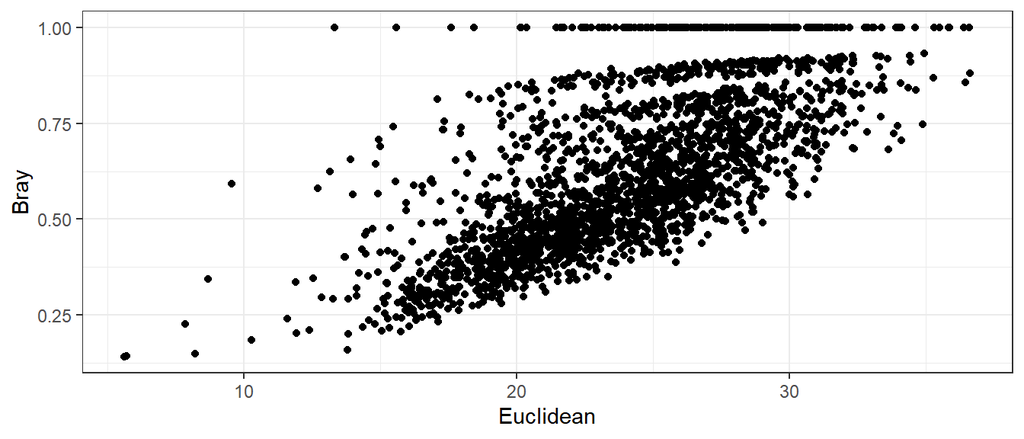

## Ординация – основной метод описания многомерных данных

## Многомерные объекты, их свойства и внешние факторы

| Элемент анализа | (син)экология | морфология | молекулярная биология |
| --- | --- | --- | --- |
| Объекты | площадки / пробы | особи / клетки и т.п. | особи / клетки и т.п. |
| Собственные свойства объектов | численность / биомасса особей разных видов | измерения, свойства | интенсивность экспрессии гена/пептида |
| Внешние факторы | свойства среды | свойства среды / особей / клеток | свойства среды / особей / клеток |

**По аналогии с одномерными линейными моделями**

- Объекты – Измерения
- Свойства объектов – Зависимая переменная
- Внешние факторы – Предикторы

## Ординация

**Ординация** (лат. *ordinatio* — расположение в порядке) — это упорядочивание объектов вдоль некоторых осей, определяющих варьирование свойств этих объектов.

Если у объектов всего два свойства, то ординация имеет вид облака точек в двух осях.

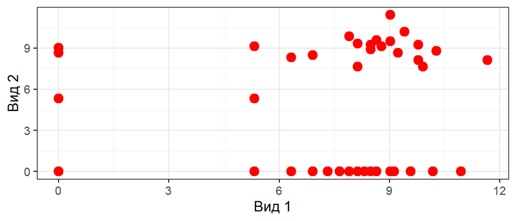

Аналогия ординации с одномерными методами – просто числовой ряд.

## Ординация в сокращенном пространстве признаков (Оrdination in reduced space)

Если признаков становится больше двух, то визуализация взаиморасположения объектов в n-мерном пространстве признаков становится невозможной. Для этого применяют разные способы получения “образа” n-мерного облака:

**Старинные методы:**

- Висконсинская полярная ординация (Bray and Curtis, 1957)

**Современные методы:**

- Метрическое многомерное шкалирование (MDS)
- Неметричекое многомерное шкалирование (nMDS)
- Метод главных компонент (PCA)
- Корреспондентный анализ (CA)

## Висконсинская полярная ординация

Это простейший прием ординации в сокращенном пространстве

Шаг 1. Подготовка данных для анализа.

Логарифмирование мы провели ранее

```r
row.names(abund_rel) <- abund$Station
```

## Висконсинская полярная ординация

Шаг 2. Вычисление матрицы сходства/различия между объектами.  
Из дидактических соображений возьмем матрицу Евклидовых расстояний.

```r
library(vegan)
E_dist <- vegdist(abund_log, method = "euclidean")
```

## Висконсинская полярная ординация

Шаг 3. Найдем наиболее различающиеся объекты (максимальное Евклидово расстояние между ними).

```
##         i Object_j Object_k Distance
## 1991 1991       44       57     36.6
```

Эти два объекта и задают ось, вдоль которой будет производиться ординация.

## Висконсинская полярная ординация

Шаг 4. Координаты каждого из объектов на этой оси могут быть найдены, согласно правилам треугольника

Возьмем любую другую точку, например “S2”

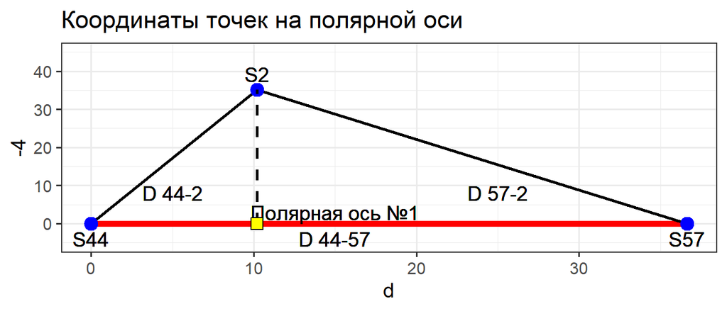

## Висконсинская полярная ординация

Шаг 5. Вычисляем координаты на полярной оси для каждого объекта.

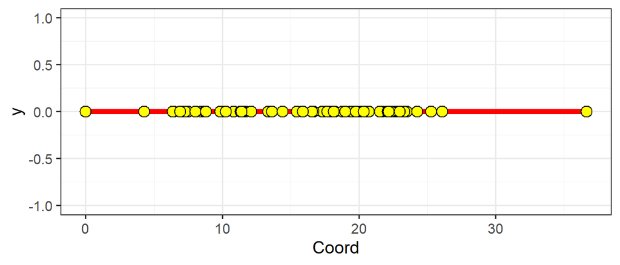

## Висконсинская полярная ординация

Шаг 6. При необходимости, находим следующую пару наиболее несходных объектов и вычисляем координаты для каждой точки на новой оси.

*At!* Одновременное изображение информации об обеих полярных осях на одной диаграмме невозможно!  
Мы не знаем как взаимосвязаны эти оси. Они могут быть неортогональны.

## Интерпретация результатов ординации

Сама по себе ординация - это лишь визуализация структуры многомерных данных.

Исследователю важно объяснить, с какими внешними факторами связана наблюдаемая ординация.

## Пример: Структура сообщества и градиент температуры

С помощью Висконсинской полярной ординации мы получили градиент точек на полярной оси.

Этот градиент связан с внешним фактором - температурой.

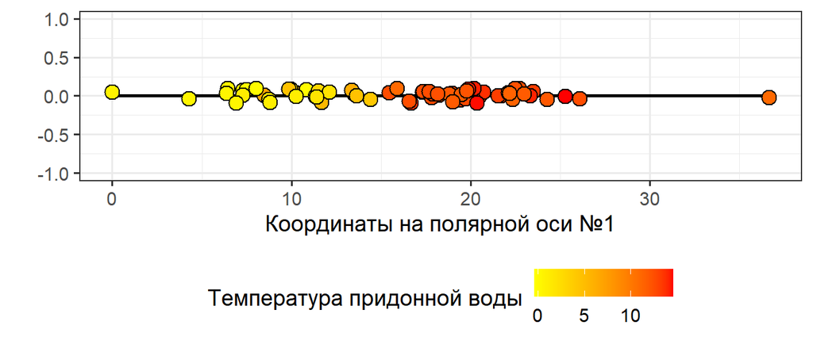

## Две схемы интерпретации

Методы интерпретации многомерных данных делят на две большие группы (ter Braak, 1987; Legendre & Legendre, 2014):

- Непрямая интерпретация (*indirect gradient analysis*, *indirect comparison*)
- Прямая интерпретация (*direct gradient analysis*, *direct comparison*)

## Методы непрямой интерпретации

Синоним – неограниченная ординация (*unconstrained ordination*).

Мы строим ординацию (или используем иной тип визуализации), основанную на свойствах самих объектов, далее пытаемся связать эту ординацию с внешними факторами.

**Методы неограниченной ординации:**

- Висконсинская полярная ординация
- неметрическое многомерное шкалирование (*non-Metric Multidimensional Scaling*, nMDS)
- анализ главных компонент (*Principal Component Analysis*, PCA)
- корреспондентный анализ (*Correspondence Analysis*, CA).

После построения ординации на нее накладывают информацию о внешних факторах:

**Простейший способ:** Построить точечные диаграммы, отражающие связь координат осей ординации с той или иной внешней переменной.

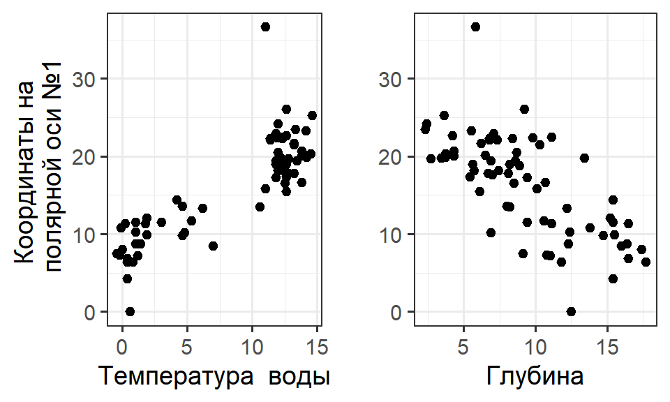

## Задание

Вычислите значения координат полярной ординации, основанной на относительных обилиях видов (`abund_rel`) и постройте точечную диаграмму, отражающую связь этой ординации с глубиной, температурой? соленостью и обводненностью грунта.

## Решение

```r
New_coord2 <- polarord(abund_rel)

Pl_1 <- qplot(hydrol$Temp, New_coord2$Coord) + labs(x = "Температура", y = "Координаты ординации")
Pl_2 <- qplot(hydrol$Depth, New_coord2$Coord) + labs(x = "Глубина", y = "Координаты ординации")
Pl_3 <- qplot(hydrol$Sal, New_coord2$Coord) + labs(x = "Соленость", y = "Координаты ординации")
Pl_4 <- qplot(hydrol$Water_content, New_coord2$Coord) + labs(x = "Обводненность", y = "Координаты ординации")
```

## Решение

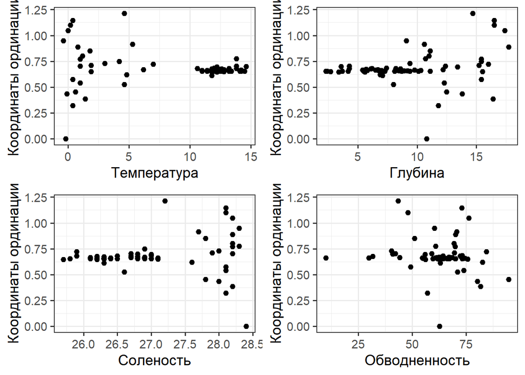

```r
grid.arrange(Pl_1, Pl_2, Pl_3, Pl_4, ncol = 2)
```

## Методы прямой интерпретации

Синоним – ограниченная ординация (*constrained ordination*).

Для построения ординации в один анализ включаются и свойства объектов и внешние факторы. Итоговая ординация отражает результат взаимосвязи свойств объектов с внешними факторами.

Методы прямой ординации позволяют тестировать гипотезы о влиянии различных внешних переменных на свойства многомерных объектов:

**Методы ограниченной ординации:**

- анализ избыточности (*Redundancy Analysis*, RDA)
- канонический корреспондентный анализ (*Canonical Correspondence Analysis*, CCA).

## Summary

- Существует два подхода к анализу многомерных данных:
- подход, основанный на линейной алгебре,
- подход, основанный на исследовании матриц сходства/различия между объектами.
- Выбор коэффициентов сходств/различия - непростая задача, решение которой зависит от структуры материала и поставленных задач. Разные коэффициенты потенциально могут давать разные результаты.
- Получить важную информацию о взаиморасположении объектов можно с помощью некоторых простейших методов.

## Что почитать

- Legendre P., Legendre L. (1998) Numerical ecology. Second english edition. Elsevier, Amsterdam. (Фундаментальный труд, описывающий большинство методов. Дается исчерпывающее обсуждение разнообразных коэффициентов сходства/различия)
- Zuur, A. F., Ieno, E. N., Smith, G. M. Analysing Ecological Data. Springer 2007 (Практически все то же самое, что в L&L, но написанное простым языком)
- Clarke, K. R., Gorley R. N. (2006) PRIMER v6: User Manual/Tutorial. PRIMER-E, Plymouth. (Очень доходчиво написанное руководство, дающее общее представление о “механике” работы многомерных методов)
- Миркин Б.М., Розенберг Г.С. Фитоценология. Принципы и методы. М., 1978. (Руководство написано в докомпьютерную эпоху, но простейшие методы изложены очень хорошо)
- Василевич В.И. Статистические методы в геоботанике. - Л.: Наука, 1969.
- Дюран Б., Оделл П. Кластерный анализ. М.: Статистика, 1977